# PCA on GATK_vcf for D. affinis PopGen data

Anjali Gupta

2024-06-18

## Credits

This code has been written using examples from two online sources - https://rpubs.com/madisondougherty/980777 and https://rpubs.com/torris459/981399.

## Data Preparation

### Set your working directory

Set your working directory to the folder where your dataset is present

```r
setwd("/Users/a948g501/Documents/GitHub/AG_Unckless_Open_Lab_Notebook/rscripts")
```

### Install and load packages

If one or more packages is not already installed for you, you can install it using `install.packages("PackageName")`

```r
# Load required libraries
library(vcfR)
library(vegan)
library(ggplot2)
library(ggpubr)
```

### Load in the SNP data

We need to read in the `.vcf` file here in order to be able to work with the data. Here, we assign the data to an object called `snps`, which is a vcfR object. This step is also important because after we run this line of code, the output that is printed tells us whether the data properly uploaded. The last line should say `"All variants processed"` and the second to last line should say `"Processed Variant: …"`, which tells us the amount of SNPs in our data.

```r
snps <- vcfR::read.vcfR("/Users/a948g501/Documents/GitHub/AG_Unckless_Open_Lab_Notebook/datafiles/filtered_SNPs_GATK_PopGen_ChrX_haploid.vcf",
                        convertNA  = TRUE)
```

[output not shown]

[output cut: 1571 more lines]

[output not shown]

### Extracting the Genotype Data from the `.vcf` File

Since `.vcf` files have a lot information included that isn’t necessary for our analysis, we need to extract the genotype data that we plan to use and convert it into a form that we can easily use in R. So, here, we extract the character data containing the genotypes, and convert it into numeric scores that we can later use in our analysis using the function `vcfR::extract.gt()` and the arguments as follows.

```r
snps_num <- vcfR::extract.gt(snps,
           element = "GT",
           IDtoRowNames  = F,
           convertNA = T,
           return.alleles = F)
```

### Rotating the Genotype Scores into Numeric Data

```r
snps_num_t <- t(snps_num)
```

Here we convert the matrix to a data frame so that we can perform the appropriate functions on the data and make the plots necessary for analysis.

```r
snps_num_df <- data.frame(snps_num_t)
```

### Remove NAs

In this step we create a function called `find_NAs()` that will tell us how many NAs are in our data frame of SNPs and print the index value of where an NA is located. When using the function, you input the row number you want to search for NAs in using bracket notation, and the function will print the indices where NAs were found within that row.

```r
find_NAs <- function(x){
  NAs_TF <- is.na(x)
  i_NA <- which(NAs_TF == TRUE)
  N_NA <- length(i_NA)

  cat("Results:",N_NA, "NAs present\n.")
  return(i_NA)
}
```

In this process, we use a `for()` loop to go through every row of the data frame and search each row individually for NAs using the `find_NAs` function. The output will contain each row’s number of NAs.

```r
# N_rows
# number of rows (individuals)
N_rows <- nrow(snps_num_t)

# N_NA
# vector to hold output (number of NAs)
N_NA   <- rep(x = 0, times = N_rows)

# N_SNPs
# total number of columns (SNPs)
N_SNPs <- ncol(snps_num_t)

# the for() loop
for(i in 1:N_rows){

  # for each row, find the location of
  ## NAs with snps_num_t()
  i_NA <- find_NAs(snps_num_t[i,])

  # then determine how many NAs
  ## with length()
  N_NA_i <- length(i_NA)

  # then save the output to
  ## our storage vector
  N_NA[i] <- N_NA_i
}
```

```
## Results: 14489 NAs present
## .Results: 21195 NAs present
## .Results: 6011 NAs present
## .Results: 767296 NAs present
## .Results: 199756 NAs present
## .Results: 129840 NAs present
## .Results: 355382 NAs present
## .Results: 931362 NAs present
## .Results: 140707 NAs present
## .Results: 396807 NAs present
## .Results: 118784 NAs present
## .Results: 139430 NAs present
## .Results: 207096 NAs present
## .Results: 446790 NAs present
## .Results: 37492 NAs present
## .Results: 316618 NAs present
## .Results: 147566 NAs present
## .Results: 240380 NAs present
## .Results: 215840 NAs present
## .Results: 112330 NAs present
## .Results: 723996 NAs present
## .Results: 361689 NAs present
## .Results: 1012547 NAs present
## .Results: 161944 NAs present
## .Results: 1317213 NAs present
## .Results: 152051 NAs present
## .Results: 168751 NAs present
## .Results: 290532 NAs present
## .Results: 258246 NAs present
## .Results: 376499 NAs present
## .Results: 254236 NAs present
## .Results: 562851 NAs present
## .Results: 127680 NAs present
## .Results: 207133 NAs present
## .Results: 450178 NAs present
## .Results: 461038 NAs present
## .Results: 323505 NAs present
## .Results: 1176835 NAs present
## .Results: 372487 NAs present
## .Results: 570690 NAs present
```

[output cut: 24 more lines]

```
## .Results: 467094 NAs present
## .Results: 149571 NAs present
## .Results: 621325 NAs present
## .Results: 759558 NAs present
## .Results: 523096 NAs present
## .Results: 641594 NAs present
## .Results: 219511 NAs present
## .Results: 154914 NAs present
## .Results: 20016 NAs present
## .Results: 47737 NAs present
## .Results: 83580 NAs present
## .Results: 419830 NAs present
## .Results: 100801 NAs present
## .Results: 76071 NAs present
## .
```

Here, we first created an object containing the number equal to 50% of the total number of columns. Then, we create a histogram demonstrating the variation in the amount of NAs found in each row of the data frame. From the graph, we see that the majority of rows had less than 400,000 NAs, but there were still some rows that had as much as 1,400,000 NAs. We then added a line for the value stored in the object cutoff50, which shows us how many of the columns were not included in the final analysis of the data.

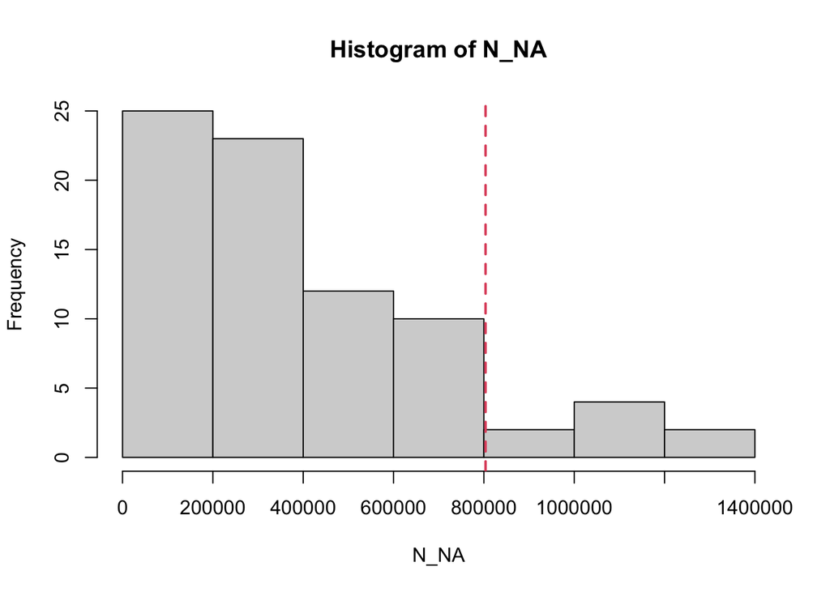

```r
# 50% of N_SNPs
cutoff50 <- N_SNPs*0.5

hist(N_NA)
abline(v = cutoff50,
       col = 2,
       lwd = 2,
       lty = 2)
```

Here, we determined how many NAs are in each row and we created an object that only contains the rows that had less than 50% of the data as NAs.

```r
percent_NA <- N_NA/N_SNPs*100

# Call which() on percent_NA
i_NA_50percent <- which(percent_NA > 50)

snps_num_t02 <- snps_num_t[-i_NA_50percent, ]
```

### Make a key of the sample names

Here, we make a key of the sample names.

```r
row_names <- row.names(snps_num_t02) # Key

row_names02 <- gsub("sample_","",row_names)

pop_id <- gsub("^([ATCG]*)(_)(.*)",
                  "\\3",
                  row_names02)
table(pop_id)
```

```
## pop_id
## Daff_SR1 Daff_SR2  Daff_ST    pool1   pool10   pool11   pool12   pool14
##        1        1        1        1        1        1        1        1
##   pool15   pool16   pool17   pool18   pool19    pool2   pool20   pool21
##        1        1        1        1        1        1        1        1
##   pool22   pool23   pool24   pool26   pool27   pool29   pool30   pool31
##        1        1        1        1        1        1        1        1
##   pool32   pool33   pool34   pool35   pool36   pool37   pool38   pool39
##        1        1        1        1        1        1        1        1
##    pool4   pool40   pool42   pool43   pool44   pool45   pool47   pool48
##        1        1        1        1        1        1        1        1
##    pool5   pool57   pool58   pool59    pool6   pool60   pool61   pool62
##        1        1        1        1        1        1        1        1
##   pool63   pool64   pool65   pool66   pool67   pool68    pool7   pool71
##        1        1        1        1        1        1        1        1
##   pool74   pool75   pool76   pool77   pool78   pool79    pool8   pool80
##        1        1        1        1        1        1        1        1
##   pool87   pool88   pool89    pool9   pool90   pool91
##        1        1        1        1        1        1
```

### Removing Invariant Columns

Here, we created the function `invar_omit()` , which removes the columns that are considered invariant from the data frame that we want to analyze. Invariant columns contain data that does not have any variance, and thus, is unnecessary to include in our analysis because it does not provide any useful information. The function we created here removes the invariant columns and then prints an output showing how many columns were removed. After creating the function, we used it on our data frame and created the new data frame, that now contains no invariant columns, `snps_no_invar`.

```r
invar_omit <- function(x){
  cat("Dataframe of dim",dim(x), "processed...\n")
  sds <- apply(x, 2, sd, na.rm = TRUE)
  i_var0 <- which(sds == 0)


  cat(length(i_var0),"columns removed\n")

  if(length(i_var0) > 0){
     x <- x[, -i_var0]
  }

  ## add return()  with x in it
  return(x)
}


snps_no_invar <- invar_omit(snps_num_t02)
```

```
## Dataframe of dim 70 1607467 processed...
## 133449 columns removed
```

First, we replaced our data frame `snps_noNAs` with the data frame that doesn’t contain invariant columns that we created in the last step. Then we used a `for()` loop to complete mean imputation on our data frame to replace all of the remaining NAs in each column with the mean of each column, which we calculated using `mean()`. In that function, we used the argument `na.rm = TRUE` to ensure that the mean could be calculated while ignoring the NAs in the column.

```r
snps_noNAs <- snps_no_invar

N_col <- ncol(snps_no_invar)
for(i in 1:N_col){

  # get the current column
  column_i <- snps_noNAs[, i]

  # get the mean of the current column
  mean_i <- mean(column_i, na.rm = TRUE)

  # get the NAs in the current column
  NAs_i <- which(is.na(column_i))

  # record the number of NAs
  N_NAs <- length(NAs_i)

  # replace the NAs in the current column
  column_i[NAs_i] <- mean_i

  # replace the original column with the
  ## updated columns
  snps_noNAs[, i] <- column_i

}
```

### Save the data

Save the data as a .csv file which can be loaded again later.

```r
write.csv(snps_noNAs, file = "ChrX_PopGenDaff_SNPs_cleaned.csv",
          row.names = F)
```

Check for the presence of the file with list.files()

```r
list.files(pattern = ".csv")
```

```
## [1] "ChrX_PopGenDaff_SNPs_cleaned.csv"
```

### Next steps:

In Part 2, we will re-load the SNPs_cleaned.csv file and carry an an analysis with PCA.